# Scenarios, stress, and historical VaR

- Show All Code
- Hide All Code
- View Source

Shocks are endomorphisms on the market; repricing stays lazy

A `Shock` is just a function from one `MarketSnapshot` to another, so a *scenario* is a named shock and a *historical VaR* is a fan of shocks — one per observed market move — repriced through the **same pure pricer**. The pricer never knows it is being stressed; `reprice_under` swaps the market underneath it and keeps everything lazy until the final collect.

**Imports**

```python
from datetime import date
import numpy as np
import polars as pl
import matplotlib.pyplot as plt

from schenberg import (
    FormulaGraph, MarketSnapshot, MarketPath, With, bind, exp, market_role,
    Scenario, ScenarioSet, reprice_under,
)
from schenberg.domain.base import SchenbergDataFrameModel
from schenberg_quarto import show_formulas

plt.rcParams.update({"figure.dpi": 110, "axes.grid": True, "grid.alpha": 0.3})
rng = np.random.default_rng(7)
```

## 1. A small forward book

A discounted forward, `PV = (F − K)·e^{−rT}`, priced from a `curves` source that carries both the forward rate and the discount rate.

```python
Fwd = market_role("forward_rate").read("curves", "forward_rate").by(
    indexer="id_indexador", payment_days="tenor_days"
)
Disc = market_role("risk_free_rate").read("curves", "risk_free_rate").by(
    indexer="id_indexador", payment_days="tenor_days"
)


class FwdInput(With[Fwd], With[Disc], SchenbergDataFrameModel):
    instrument_id: str
    indexer: str
    strike: float
    notional: float
    payment_days: int


g = FormulaGraph("fwd_book", input=FwdInput)


@g.formula(symbol="T")
def year_fraction(payment_days):
    return payment_days / 252.0


@g.formula(symbol="DF")
def discount_factor(risk_free_rate, year_fraction):
    return exp(-risk_free_rate * year_fraction)


@g.formula(symbol="V")
def value(forward_rate, strike, notional, discount_factor):
    return notional * (forward_rate - strike) * discount_factor


g.returns("output", instrument_id="instrument_id", value="value")


def price_book(trades: pl.LazyFrame, market: MarketSnapshot) -> pl.LazyFrame:
    return g.plan(bind(trades, market, FwdInput), view="output")
```

```python
show_formulas(g)
```

**Formulas**

$$T = \frac{\mathrm{payment\_days}}{252.0}$$

$$DF = e^{-\mathrm{risk\_free\_rate} \cdot \mathrm{year\_fraction}}$$

$$V = \mathrm{notional} \cdot \left(\mathrm{forward\_rate} - \mathrm{strike}\right) \cdot \mathrm{discount\_factor}$$

```python
trades = pl.DataFrame(
    {
        "instrument_id": ["FWD-1Y", "FWD-2Y", "FWD-SHORT"],
        "indexer": ["DI", "DI", "DI"],
        "strike": [100.0, 100.0, 110.0],
        "notional": [1_000.0, 1_500.0, -800.0],
        "payment_days": [252, 504, 252],
    }
).lazy()

base_market = (
    MarketSnapshot.at(date(2026, 6, 6))
    .source(
        "curves",
        pl.DataFrame(
            {
                "id_indexador": ["DI", "DI"],
                "tenor_days": [252, 504],
                "forward_rate": [105.0, 108.0],
                "risk_free_rate": [0.10, 0.11],
            }
        ),
        unique_by=("id_indexador", "tenor_days"),
    )
    .build()
)

price_book(trades, base_market).collect()
```

shape: (3, 8)

| risk_free_rate f64 | forward_rate f64 | instrument_id str | indexer str | strike f64 | notional f64 | payment_days i64 | value f64 |
| --- | --- | --- | --- | --- | --- | --- | --- |
| 0.1 | 105.0 | "FWD-1Y" | "DI" | 100.0 | 1000.0 | 252 | 4524.18709 |
| 0.11 | 108.0 | "FWD-2Y" | "DI" | 100.0 | 1500.0 | 504 | 9630.225576 |
| 0.1 | 105.0 | "FWD-SHORT" | "DI" | 110.0 | -800.0 | 252 | 3619.349672 |

## 2. Named stress scenarios

`MarketPath` builds a shock by pointing at a source column and transforming it. Here are three hand-named stresses, repriced in one call.

```python
fwd_path = MarketPath("curves").column("forward_rate")

stresses = ScenarioSet.of(
    Scenario("forward -5", fwd_path.modify(lambda f: f - 5.0)),
    Scenario("forward +5", fwd_path.modify(lambda f: f + 5.0)),
    Scenario("rate +100bp", MarketPath("curves").column("risk_free_rate").modify(lambda r: r + 0.01)),
)

stress_pnl = (
    reprice_under(price_book, trades, base_market, stresses)
    .group_by("scenario")
    .agg(pl.col("value_diff").sum().alias("book_pnl"))
    .sort("book_pnl")
)
stress_pnl.collect()
```

shape: (3, 2)

| scenario str | book_pnl f64 |
| --- | --- |
| "forward -5" | -6923.728403 |
| "rate +100bp" | -271.720787 |
| "forward +5" | 6923.728403 |

## 3. Historical VaR — a fan of one-day shocks

Take a year of (here, simulated) daily forward-rate moves, turn each day into a `Scenario`, and reprice the book through all of them. The portfolio P&L is the sum of instrument value changes per scenario.

```python
n_days = 250
daily_moves = rng.normal(0.0, 1.5, size=n_days)  # forward-rate points / day

history = ScenarioSet.of(
    *(
        Scenario(f"day_{i}", fwd_path.modify(lambda f, m=float(m): f + m))
        for i, m in enumerate(daily_moves)
    )
)

pnl = (
    reprice_under(price_book, trades, base_market, history)
    .group_by("scenario")
    .agg(pl.col("value_diff").sum().alias("pnl"))
    .collect()
    .get_column("pnl")
    .to_numpy()
)

var_95 = -np.quantile(pnl, 0.05)
var_99 = -np.quantile(pnl, 0.01)
es_97_5 = -pnl[pnl <= np.quantile(pnl, 0.025)].mean()

pl.DataFrame(
    {
        "metric": ["VaR 95%", "VaR 99%", "Expected Shortfall 97.5%"],
        "loss": [var_95, var_99, es_97_5],
    }
)
```

shape: (3, 2)

| metric str | loss f64 |
| --- | --- |
| "VaR 95%" | 3507.134076 |
| "VaR 99%" | 4402.368818 |
| "Expected Shortfall 97.5%" | 4445.395024 |

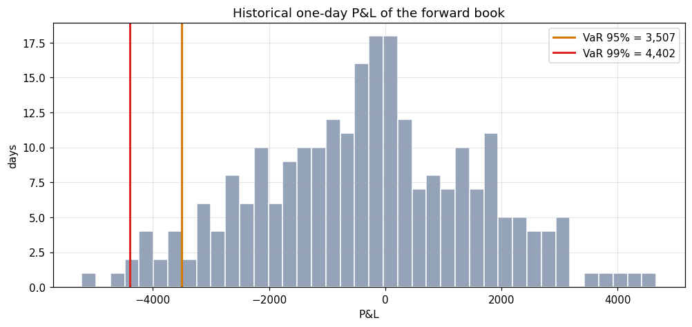

```python
fig, ax = plt.subplots(figsize=(9, 4.2), constrained_layout=True)
ax.hist(pnl, bins=40, color="#94a3b8", edgecolor="white")
ax.axvline(-var_95, color="#d97706", lw=2, label=f"VaR 95% = {var_95:,.0f}")
ax.axvline(-var_99, color="#dc2626", lw=2, label=f"VaR 99% = {var_99:,.0f}")
ax.set_title("Historical one-day P&L of the forward book")
ax.set_xlabel("P&L"); ax.set_ylabel("days"); ax.legend()
plt.show()
```

Every loss number above came from repricing the *unmodified* pricer under a shocked market — the risk engine and the pricing engine never blur together. `reprice_under` returned a single `LazyFrame`; the only `.collect()` is the one we wrote.